# Evigene transcriptome filter

Fernando

July 10, 2018

This document describes the content of the consensus assembly generated by Evidential gene tool using multiple spades assemblies with different k-mer sizes. The pipeline used to construct the denovo transcriptome assembly is described below:

1. Sampling 20M reads frome each biological condition.
2. De novo transcriptome assembly in each condition using spades with k-mer sizes = 21,25,75 and 81
3. De novo transcriptome assembly with auto-detected k-mer size using spades
4. Reduce redundancy on each assembly at 96% similarity with CD-HIT-EST
5. Merging of all transcripts ( total transcriptomes = 75 total transcripts = 929,578)
6. clustering and selection of best transcripts per locus using Evidential gene.

The table below sumarizes the content and structure of the resultant assembly **ZC_WD_denovo.01**

| Assembly statistics before filtering |  |  |  |  |  |
| --- | --- | --- | --- | --- | --- |
| **content** |  |  |  | **Continuity** |  |
| No. transcripts | 71005 |  |  | N50 | 1535, n = 12495 |
| Largest transcript | 32374 |  |  | N70 | 904, n = 23828 |
| Gaps | 3320 |  |  | N90 | 373, n = 47183 |
| N count | 44473 |  |  | N100 | 148, n = 71005 |

## Transcripts quality scores

Transcripts were scored based on three quality meassures to identify spurious transcripts to be filtered out.

**1) transcript architecture:** Transrate was used to generate predictions of transcript architecture, including presence / absence of UTR, length and percentage of Open reading Frame, length and percentage of Coding sequence

**2) coverage of reference proteins:** A reference protein database was built by merging proteomes of the following species from lepbase: B.mori, D. plexippus, H. erato, H. melpomene, P. xunthus, P. senae. Transcripts were blased against this data base to identify the quality of their similarity using tblastx

**3) Read mapping coverage:** A sample of 20M reads per condition was mapped against the transcriptome using Bowtie to identify transcripts that do not show good coverage.

```r
## Load data .....................................................

coverage <- read.table('coverage.txt', header=TRUE, row.names = 1)
structure <- read.csv('contigs.csv', row.names = 1)

# Rearange data ..................................................

cov <- coverage[order(as.vector(row.names(coverage))),]
str <- structure[order(as.vector(row.names(structure))),]

# Add average coverage to str ....................................

str$coverage <- rowSums(cov)
```

The graphs below summarize the results of some of the quality metrics obtained in the quality test.

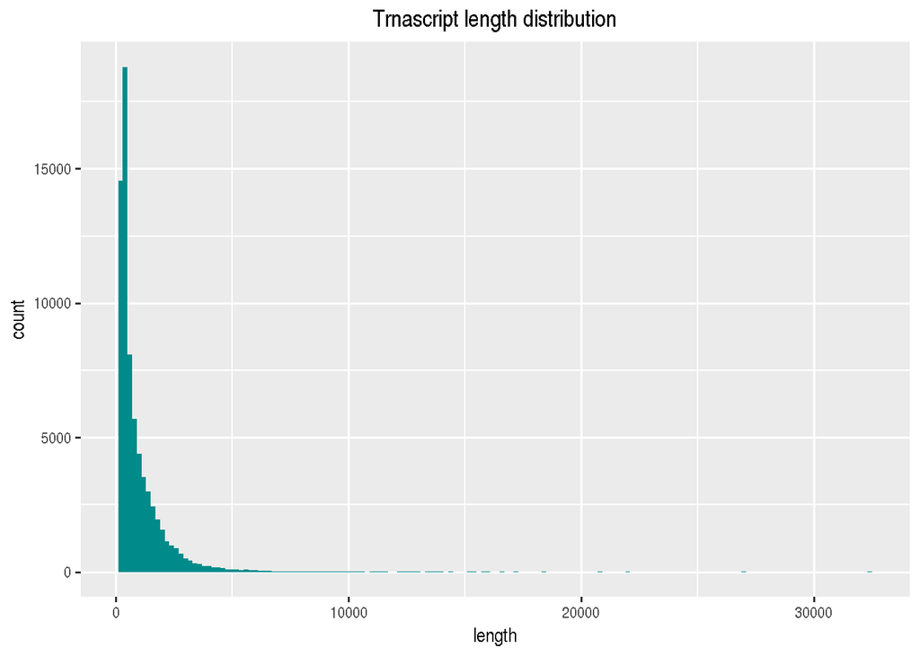

```r
## Plot transcript length ............................

ggplot(data = str, aes(x = length)) +
  geom_histogram(binwidth = 200, fill = 'darkcyan')+
        ggtitle('Trnascript length distribution')+
        theme(plot.title = element_text(hjust = 0.5))
```

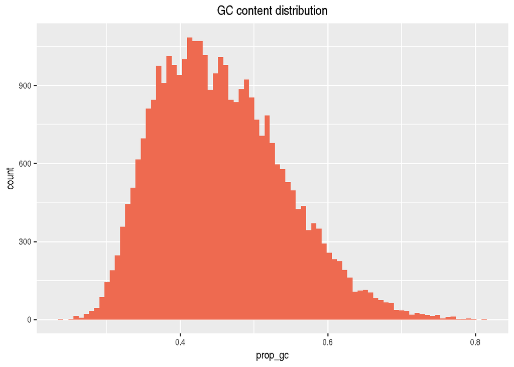

```r
## Plot GC content ...................................

ggplot( data = na.omit(str), aes(x = prop_gc)) +
  geom_histogram(binwidth = 0.007, fill = 'coral2')+
        ggtitle('GC content distribution')+
        theme(plot.title = element_text(hjust = 0.5))
```

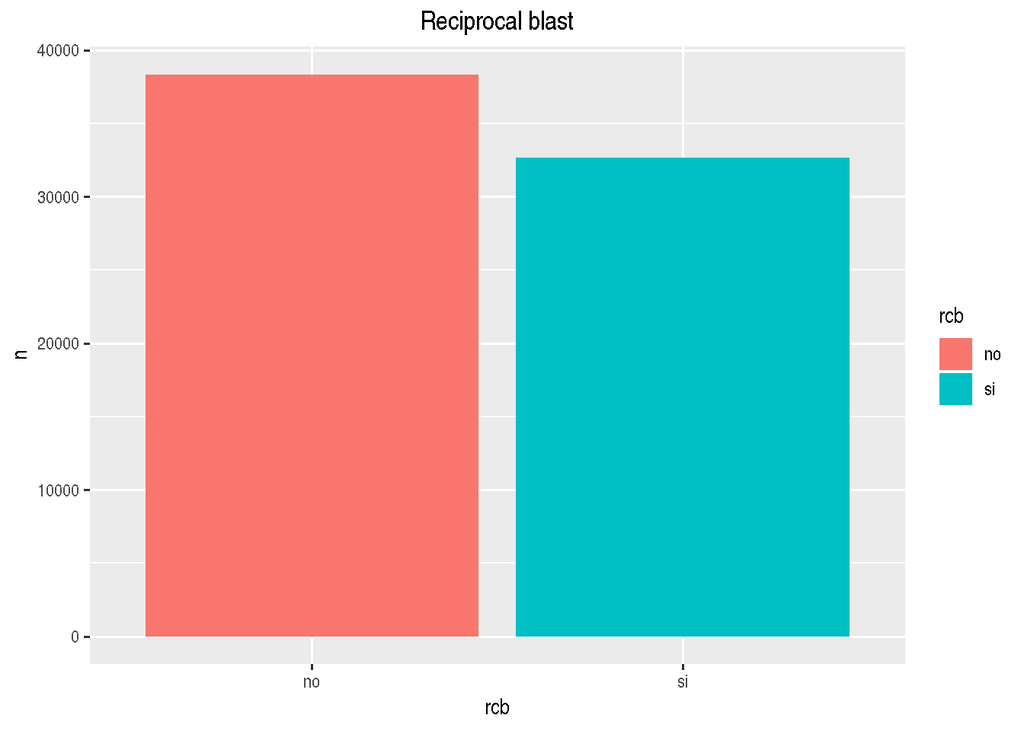

```r
## Plot reciprocal blast ............................

blast <- data.frame(rcb = c('no','si'), n= as.vector(table(str$has_crb)))

ggplot( data = blast, aes(rcb, n, fill = rcb)) +
  geom_bar(stat = 'identity')+
  ggtitle('Reciprocal blast')+
        theme(plot.title = element_text(hjust = 0.5))
```

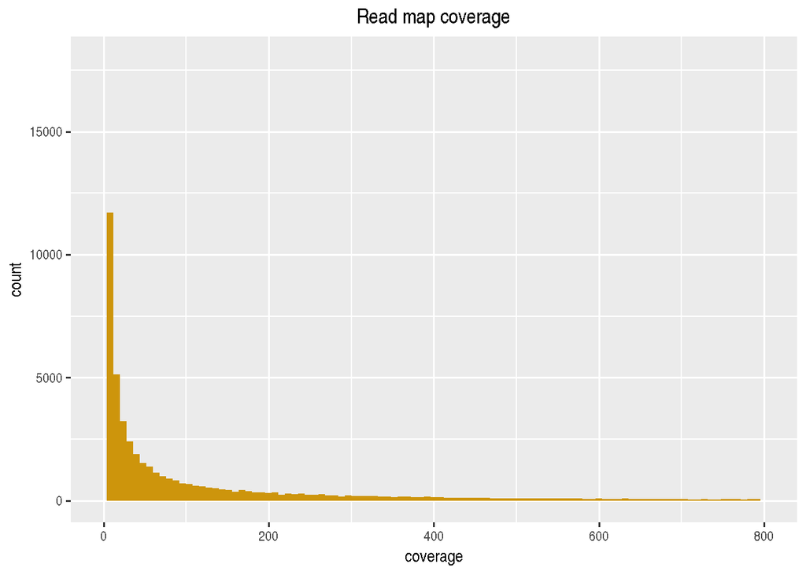

```r
## Plot read coverage ...............................

ggplot(str, aes(x = coverage))+
  geom_histogram(binwidth = 8, fill = 'darkgoldenrod3')+
  ggtitle('Read map coverage')+
  scale_x_continuous(limits = c(0, 800)) +
  theme(plot.title = element_text(hjust = 0.5))
```

## Filtering out low quality transcripts

Thes results above shows that the transcriptome contains spurious transcripts of low quality that are not supported by the sample of reads. Contigs were clasified into three cathegories described below:

**high quality:** Transcripts with concordant reciprocal blast hit and reference coverage higher than 0.8 or transcripts that are supported by reads for more than 100 reads.

**medium quality:** Transcripts that regardles of other metrics are supported by more than 10 reads.

**low quality:** All other transcrits.

```r
str$quality <- ifelse(str$has_crb == 'true' & str$reference_coverage > 0.80 | str$coverage >= 100,
                      'high', ifelse(coverage >=10, 'medium','low'))
```

A total of 46141 transcripts of low quality were filtered out. the table below shows the content of the resulting filered transcriptome.

[output not shown]

```r
tr2 <- str[str$quality != 'low',]

write(row.names(tr2), 'good_transcripts.txt')
```

The plots below show the quality values of the filtered transcripts.

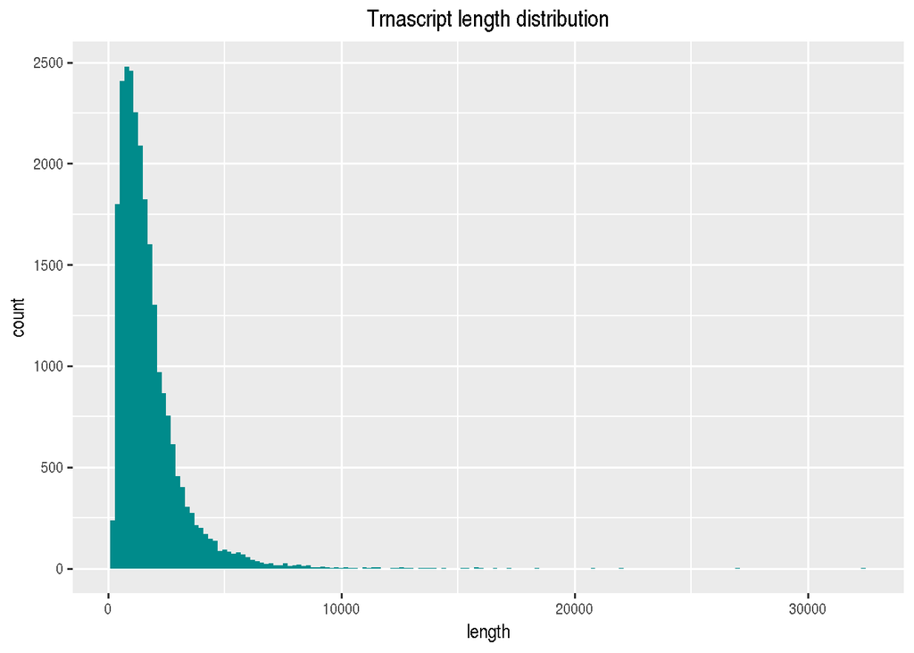

```r
## Plot transcript length ............................

ggplot(data = tr2, aes(x = length)) +
  geom_histogram(binwidth = 200, fill = 'darkcyan')+
        ggtitle('Trnascript length distribution')+
        theme(plot.title = element_text(hjust = 0.5))
```

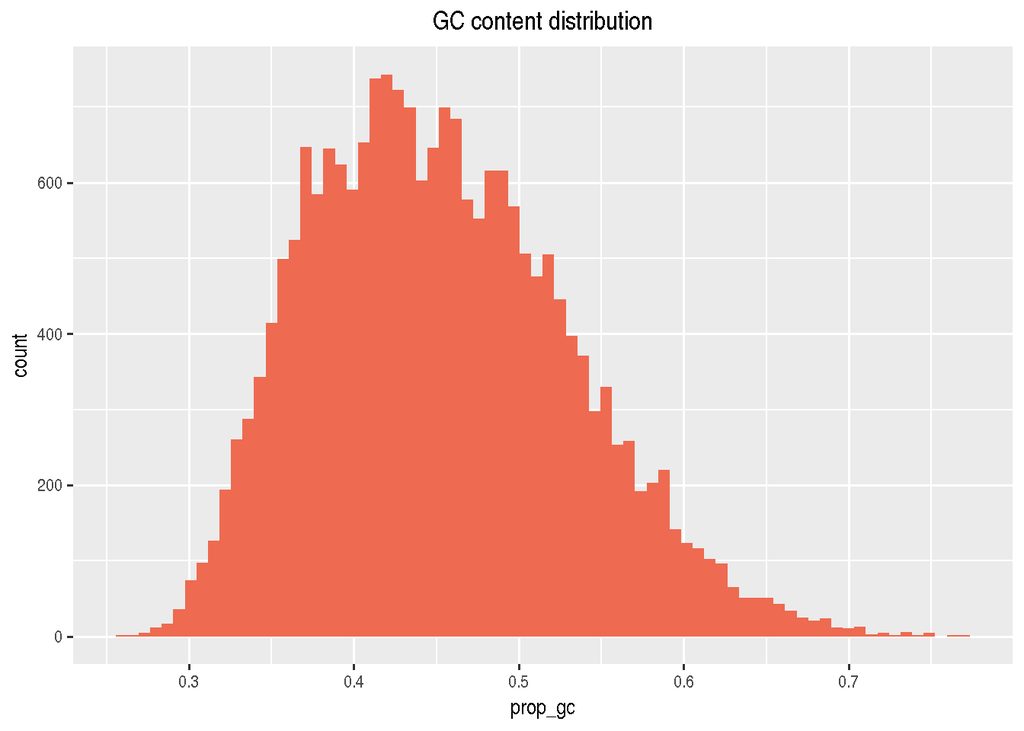

```r
## Plot GC content ...................................

ggplot( data = na.omit(tr2), aes(x = prop_gc)) +
  geom_histogram(binwidth = 0.007, fill = 'coral2')+
        ggtitle('GC content distribution')+
        theme(plot.title = element_text(hjust = 0.5))
```

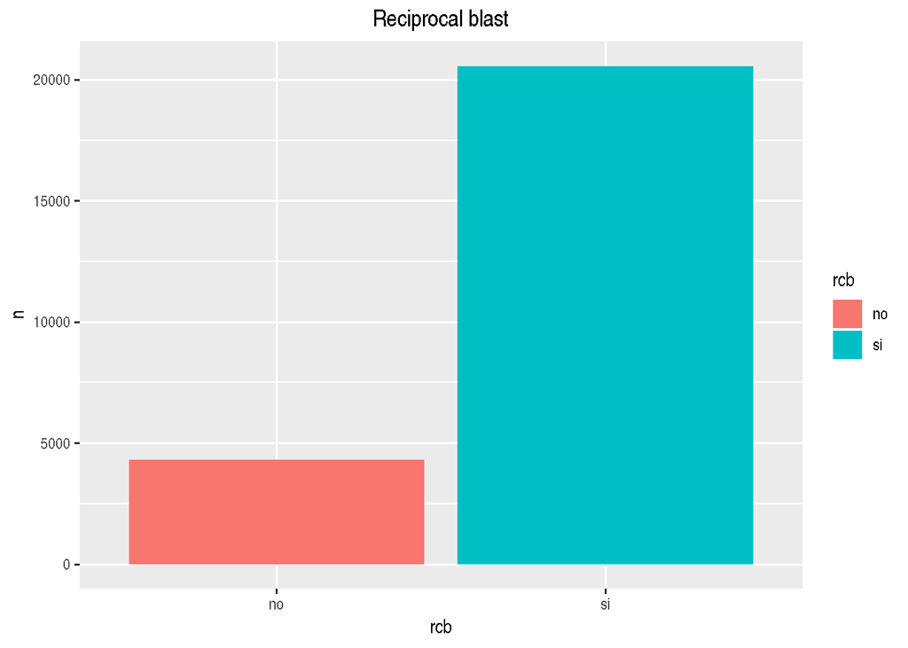

```r
## Plot reciprocal blast ............................

blast2 <- data.frame(rcb = c('no','si'), n= as.vector(table(tr2$has_crb)))

ggplot( data = blast2, aes(rcb, n, fill = rcb)) +
  geom_bar(stat = 'identity')+
  ggtitle('Reciprocal blast')+
        theme(plot.title = element_text(hjust = 0.5))
```

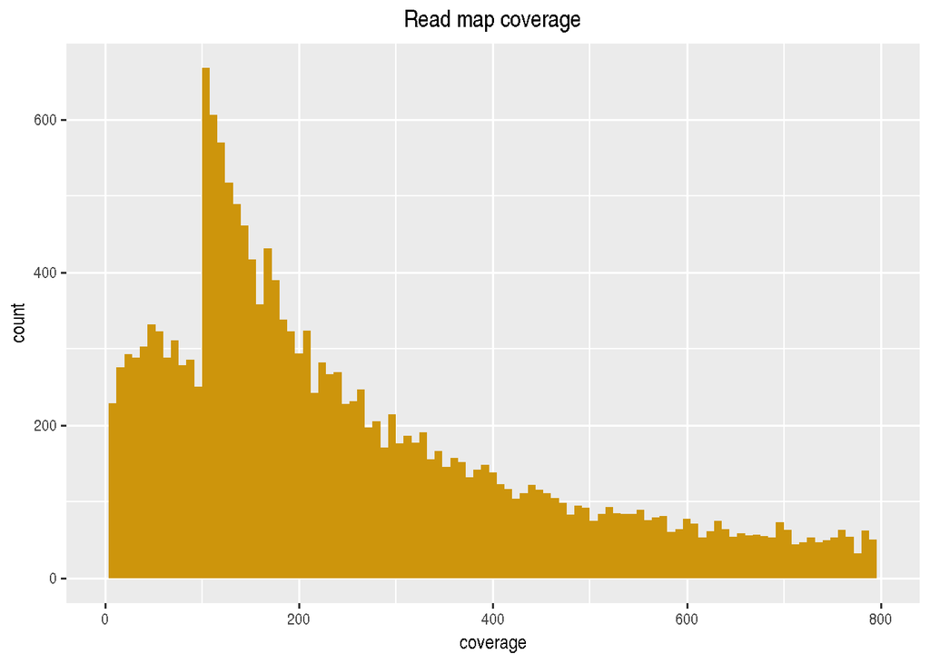

```r
## Plot read coverage ...............................

ggplot(tr2, aes(x = coverage))+
  geom_histogram(binwidth = 8, fill = 'darkgoldenrod3')+
  ggtitle('Read map coverage')+
  scale_x_continuous(limits = c(0, 800)) +
  theme(plot.title = element_text(hjust = 0.5))
```

### BUSCO completness

The completness of the transcriptome was evaluated with BUSCO, using the Endopterigota data base with 2442 single copy orthologs.

the table and chart below shows the results.

| Busco Completness |  |  |
| --- | --- | --- |
| **cathegory** | **N** | **Percentage** |
| Complete | 2169 | 88.9% |
| Fragmented | 80 | 3.3% |
| Missing | 193 | 7.8% |

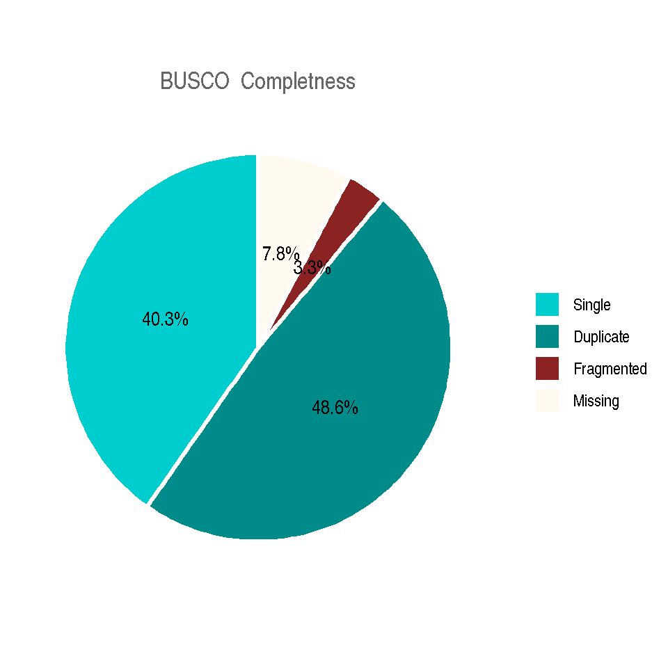

```r
df <- data.frame(
  group = c("Single", "Duplicate", "Fragmented", "Missing"),
  value = c(40.3, 48.6, 3.3,7.8)
)

df$group <- factor(df$group, levels = c('Single','Duplicate','Fragmented','Missing'))

pie <- ggplot(df, aes("", value, fill = group)) +
  geom_bar(width = 1, size = 1, color = "white", stat = "identity") +
  coord_polar("y", start = 0) +
  geom_text(aes(label = paste0(value, "%")),
            position = position_stack(vjust = 0.5)) +
  labs(x = NULL, y = NULL, fill = NULL,
       title = "BUSCO  Completness") +
  guides(fill = guide_legend(reverse = FALSE)) +
  scale_fill_manual(values = c("cyan3", "cyan4","brown4","floralwhite")) +
  theme_classic() +
  theme(axis.line = element_blank(),
        axis.text = element_blank(),
        axis.ticks = element_blank(),
        plot.title = element_text(hjust = 0.5, color = "#666666"))
pie
```